# Affinity of single motifs

Melanie (1028-02098-001-001)

February 24, 2026

# Introduction

The goal of this analysis is to visualize motif affinity effects on single motifs and highlight the directional impact of pioneering TFs. We will do this by visualizing experimental results, marginalized predictions, and perturbations of in vivo sequences, predicted by our models.

# Computational Setup

```r
#Standard packages
library(rtracklayer) ; library(GenomicRanges); library(magrittr) ; library(Biostrings)
library(ggplot2) ; library(reshape2); library(plyranges); library(Rsamtools); library(parallel)
library(dplyr); library(data.table); library(patchwork); library(readr); library(testit)

#KNITR Options
setwd("/n/projects/mw2098/publications/2024_weilert_acc/code/2_analysis/")
figure_filepath<-"figures/11_motif_affinity"
options(knitr.figure_dir=figure_filepath, java.parameters = "- Xmx6g")

#Lab sources
source("scripts/r/granges_common.r")
source("scripts/r/metapeak_common.r")
source("scripts/r/knitr_common.r")
source("scripts/r/caching.r")
source("scripts/r/metapeak_functions.r")

#Specific sources
library(BSgenome.Mmusculus.UCSC.mm10)
library(TxDb.Mmusculus.UCSC.mm10.knownGene)
library(ggseqlogo)
source("scripts/r/motif_functions.r")

#Pre-existing variables
threads <- 5
bsgenome<-BSgenome.Mmusculus.UCSC.mm10
txdb<-TxDb.Mmusculus.UCSC.mm10.knownGene

#model information
tasks<-c('oct4', 'sox2', 'nanog', 'klf4', 'zic3')
motif_to_task.list<-list('Oct4-Sox2' = 'oct4', 'Oct4' = 'oct4', 'Sox2' = 'sox2', 'Klf4' = 'klf4', 'Zic3' = 'zic3', 'Nanog' = 'nanog')
motif_to_task.df<-data.frame(task = motif_to_task.list %>% unlist, motif = names(motif_to_task.list))

input_length<-2032
output_length<-1000
flank_length<-(input_length - output_length)/2

#experimental data information
motifs.path<-'tsv/mapped_motifs/all_instances_curated_0based_w_perturb.tsv.gz'
regions.path<-'tsv/mapped_motifs/all_islands_curated_1based_w_experimental_data.tsv.gz'
marg.path<-'tsv/insilico/marginalizations/motifs/all_marginalizations.tsv.gz'
showcase.path<-'tsv/insilico/marginalizations/motifs/all_showcase_profiles.tsv.gz'

motifs_w_alternate_perturbs.path<-'tsv/mapped_motifs/all_instances_curated_0based_w_alternate_perturb.tsv.gz'
alternate_marg.path<-'tsv/insilico/marginalizations/motifs/all_alternate_marginalizations.tsv.gz'

cov.bw.list<-list(zic3 = list(pos = 'bw/mesc_zic3_nexus_combined_normalized_positive.bw',
                              neg = 'bw/mesc_zic3_nexus_combined_normalized_negative.bw'),
                  oct4 = list(pos = 'bw/mesc_oct4_nexus_combined_normalized_positive.bw',
                              neg = 'bw/mesc_oct4_nexus_combined_normalized_negative.bw'),
                  sox2 = list(pos = 'bw/mesc_sox2_nexus_combined_normalized_positive.bw',
                              neg = 'bw/mesc_sox2_nexus_combined_normalized_negative.bw'),
                  klf4 = list(pos = 'bw/mesc_klf4_nexus_combined_normalized_positive.bw',
                              neg = 'bw/mesc_klf4_nexus_combined_normalized_negative.bw'),
                  nanog = list(pos = 'bw/mesc_nanog_nexus_combined_normalized_positive.bw',
                               neg = 'bw/mesc_nanog_nexus_combined_normalized_negative.bw'),
                  atac = list(pos = 'bw/mesc_native_atac_cutsites_combined.bw',
                              neg = 'bw/mesc_native_atac_cutsites_combined.bw'))
```

# Import motifs and their associated data

Read in motifs with perturbation scores

```r
motifs.df<-readr::read_tsv(motifs.path)
regions.df<-readr::read_tsv(regions.path)
```

Import marginalization scores and their associated sequences.

```r
marg.df<-readr::read_tsv(marg.path)
```

Join marginalization and perturbation scores with motifs.

```r
motifs.df<-motifs.df %>% dplyr::left_join(marg.df) %>% as.data.frame
```

# Compare binding and accessibility prediction scores

Compare marginalization scores relative to accessibility and binding models. First, assign task-specific values.

```r
motifs.df<-lapply(names(motif_to_task.list), function(x){
  motif.df<-motifs.df %>% dplyr::filter(motif==x)
  motif.df$bind_marg<-motif.df[[paste0(motif_to_task.list[[x]], '_marg')]]
  motif.df$acc_marg<-motif.df[['atac_wt_marg']]

  motif.df$bind_perturb<-log(motif.df[[paste0('bpnet_osknz/', motif_to_task.list[[x]], '/WT/pred_sum')]]) -
    log(motif.df[[paste0('bpnet_osknz/', motif_to_task.list[[x]], '/dA/pred_sum')]])
  motif.df$acc_perturb<-log(motif.df$`atac_wt/atac/WT/pred_sum`) - log(motif.df$`atac_wt/atac/dA/pred_sum`)
  motif.df<-motif.df %>% dplyr::left_join(., regions.df %>%
                                            dplyr::select(region_id, atac_obs, atac_pred, !!sym(motif_to_task.list[[x]]), !!sym(paste0(motif_to_task.list[[x]], '_pred')))) %>%
    dplyr::rename(bind_obs = !!sym(motif_to_task.list[[x]]),
                  bind_pred =!!sym(paste0(motif_to_task.list[[x]], '_pred')))

  return(motif.df)
}) %>% rbindlist()
```

Check the fold-change difference between top5% and bottom5% of each motif

```r
motifs.df %>%
  dplyr::group_by(motif) %>%
  dplyr::summarize(bind_marg_bottom5 = quantile(bind_marg, .05),
                   bind_marg_top5 = quantile(bind_marg, .95),
                   bind_fold_change = bind_marg_top5/bind_marg_bottom5,
                   acc_marg_bottom5 = quantile(acc_marg, .05),
                   acc_marg_top5 = quantile(acc_marg, .95),
                   acc_fold_change = acc_marg_top5/acc_marg_bottom5)  %>%
  as.data.frame
```

```
##       motif bind_marg_bottom5 bind_marg_top5 bind_fold_change acc_marg_bottom5
## 1      Klf4        0.04760500      0.4929750        10.355530       0.05587480
## 2     Nanog       -0.00583240      0.0799336       -13.705096      -0.02989560
## 3      Oct4        0.03628031      0.2442613         6.732613       0.07417056
## 4 Oct4-Sox2        0.02967745      0.7867802        26.511044       0.02020980
## 5      Sox2        0.01598850      0.1574055         9.844920       0.02254580
## 6      Zic3        0.03376580      0.7665943        22.703277      -0.00849760
##   acc_marg_top5 acc_fold_change
## 1     0.3204094        5.734417
## 2     0.0349107       -1.167754
## 3     0.2873913        3.874736
## 4     0.8303845       41.088211
## 5     0.1516709        6.727235
## 6     0.0895820      -10.542035
```

Plot observed scores relative to accessibility and binding models.

```r
#Plot relationship between binding and accessibility
bind_vs_acc_obs.plot.list<-lapply(names(motif_to_task.list), function(x){
  motif.df<-motifs.df %>% dplyr::filter(motif==x)
  g<-ggplot(motif.df, aes(x = log(bind_obs), y = log(atac_obs)))+
    geom_hline(yintercept = 0, linetype = 'dotted')+
    geom_vline(xintercept = 0, linetype = 'dotted')+
    ggrastr::geom_point_rast(aes(color = seq_match_quantile), size = .1)+
    ggpubr::stat_cor(method = 'spearman', label.x.npc = 'left', label.y.npc = 'top')+
    scale_color_gradientn(colours = viridis(5), name = 'PWM score %ile')+
    scale_x_continuous(name = 'Binding obs.', limits = c(-2.5, 6))+
    scale_y_continuous(name = 'Acc obs.', limits = c(0, 10))+
    ggtitle(x)+
    theme_classic() + theme(legend.position = 'bottom')
  return(g)
})
bind_vs_acc_obs.plot<-wrap_plots(bind_vs_acc_obs.plot.list, nrow = 1)
ggsave(paste0(figure_filepath, '/bind_obs_vs_acc_obs_vs_ic_scatter.png'), bind_vs_acc_obs.plot, height = 4, width = 20)
ggsave(paste0(figure_filepath, '/bind_obs_vs_acc_obs_vs_ic_scatter.pdf'), bind_vs_acc_obs.plot, height = 4, width = 20)
```

Plot predicted scores relative to accessibility and binding models.

```r
#Plot relationship between binding and accessibility
bind_vs_acc_pred.plot.list<-lapply(names(motif_to_task.list), function(x){
  motif.df<-motifs.df %>% dplyr::filter(motif==x)
  g<-ggplot(motif.df, aes(x = log(bind_pred), y = log(atac_pred)))+
    geom_hline(yintercept = 0, linetype = 'dotted')+
    geom_vline(xintercept = 0, linetype = 'dotted')+
    ggrastr::geom_point_rast(aes(color = seq_match_quantile), size = .1)+
    ggpubr::stat_cor(method = 'spearman', label.x.npc = 'left', label.y.npc = 'top')+
    scale_color_gradientn(colours = viridis(5), name = 'PWM score %ile')+
    scale_x_continuous(name = 'Binding pred.', limits = c(1, 12))+
    scale_y_continuous(name = 'Acc pred.', limits = c(2, 10))+
    ggtitle(x)+
    theme_classic() + theme(legend.position = 'bottom')
  return(g)
})
bind_vs_acc_pred.plot<-wrap_plots(bind_vs_acc_pred.plot.list, nrow = 1)
ggsave(paste0(figure_filepath, '/bind_pred_vs_acc_pred_vs_ic_scatter.png'), bind_vs_acc_pred.plot, height = 4, width = 20)
ggsave(paste0(figure_filepath, '/bind_pred_vs_acc_pred_vs_ic_scatter.pdf'), bind_vs_acc_pred.plot, height = 4, width = 20)
```

Plot marginalization scores relative to accessibility and binding models.

```r
#Plot relationship between binding and accessibility
bind_vs_acc_marg.plot.list<-lapply(names(motif_to_task.list), function(x){
  motif.df<-motifs.df %>% dplyr::filter(motif==x)

  if (x=='Sox2'){
    #Aesthetic zoom for nice figure formation
    g_zoom<-ggplot(motif.df, aes(x = bind_marg, y = acc_marg))+
      geom_hline(yintercept = 0, linetype = 'dotted')+
      geom_vline(xintercept = 0, linetype = 'dotted')+
      ggrastr::geom_point_rast(aes(color = seq_match_quantile), size = 1)+
      ggpubr::stat_cor(method = 'spearman', label.x.npc = 'left', label.y.npc = 'top')+
      scale_color_gradientn(colours = viridis(5), name = 'PWM score %ile')+
      scale_x_continuous(name = 'Binding marg.', limits = c(-.1, .25))+
      scale_y_continuous(name = 'Acc marg.', limits = c(-.1, .25))+
      ggtitle(x)+
      theme_classic() + theme(legend.position = 'bottom')
    ggsave(paste0(figure_filepath, '/bind_marg_vs_acc_marg_vs_ic_scatter_sox2_zoom.png'), g_zoom, height = 4, width = 4)
    ggsave(paste0(figure_filepath, '/bind_marg_vs_acc_marg_vs_ic_scatter_sox2_zoom.pdf'), g_zoom, height = 4, width = 4)
  }

  g<-ggplot(motif.df, aes(x = bind_marg, y = acc_marg))+
    geom_hline(yintercept = 0, linetype = 'dotted')+
    geom_vline(xintercept = 0, linetype = 'dotted')+
    ggrastr::geom_point_rast(aes(color = seq_match_quantile), size = .1)+
    ggpubr::stat_cor(method = 'spearman', label.x.npc = 'left', label.y.npc = 'top')+
    scale_color_gradientn(colours = viridis(5), name = 'PWM score %ile')+
    scale_x_continuous(name = 'Binding marg.', limits = c(-1, 4))+
    scale_y_continuous(name = 'Acc marg.', limits = c(-1, 3))+
    ggtitle(x)+
    theme_classic() + theme(legend.position = 'bottom')


  return(g)
})
bind_vs_acc_marg.plot<-wrap_plots(bind_vs_acc_marg.plot.list, nrow = 1)
ggsave(paste0(figure_filepath, '/bind_marg_vs_acc_marg_vs_ic_scatter.png'), bind_vs_acc_marg.plot, height = 4, width = 20)
ggsave(paste0(figure_filepath, '/bind_marg_vs_acc_marg_vs_ic_scatter.pdf'), bind_vs_acc_marg.plot, height = 4, width = 20)
```

Plot binding contribution scores with the accessibility contribution scores.

```r
#Plot relationship between binding and accessibility
bind_vs_acc_contrib.plot.list<-lapply(names(motif_to_task.list), function(x){
  motif.df<-motifs.df %>% dplyr::filter(motif==x)
  g<-ggplot(motif.df, aes(x = bind_contrib, y = acc_contrib))+
    geom_hline(yintercept = 0, linetype = 'dotted')+
    geom_vline(xintercept = 0, linetype = 'dotted')+
    ggrastr::geom_point_rast(aes(color = seq_match_quantile), size = .1)+
    ggpubr::stat_cor(method = 'spearman', label.x.npc = 'left', label.y.npc = 'top')+
    scale_color_gradientn(colours = viridis(5), name = 'PWM score %ile')+
    scale_x_continuous(name = 'Binding contrib.', limits = c(-.5, 2))+
    scale_y_continuous(name = 'Acc contrib.', limits = c(-.5, 2))+
    ggtitle(x)+
    theme_classic() + theme(legend.position = 'bottom')
  return(g)
})
bind_vs_acc_contrib.plot<-wrap_plots(bind_vs_acc_contrib.plot.list, nrow = 1)
ggsave(paste0(figure_filepath, '/bind_contrib_vs_acc_contrib_vs_ic_scatter.png'), bind_vs_acc_contrib.plot, height = 4, width = 20)
ggsave(paste0(figure_filepath, '/bind_contrib_vs_acc_contrib_vs_ic_scatter.pdf'), bind_vs_acc_contrib.plot, height = 4, width = 20)
```

Plot binding marginalization scores relative to PWM scores

```r
#Plot relationship between binding and accessibility
bind_vs_ic_marg.plot.list<-lapply(names(motif_to_task.list), function(x){
  motif.df<-motifs.df %>% dplyr::filter(motif==x)
  g<-ggplot(motif.df, aes(x = bind_marg, y = seq_match_quantile))+
    geom_hline(yintercept = 0, linetype = 'dotted')+
    geom_vline(xintercept = 0, linetype = 'dotted')+
    ggrastr::geom_point_rast(size = .1)+
    ggpubr::stat_cor(method = 'spearman', label.x.npc = 'left', label.y.npc = 'top')+
    # scale_color_gradientn(colours = viridis(5), name = 'PWM score %ile')+
    scale_x_continuous(name = 'Binding marg.')+
    scale_y_continuous(name = 'PWM score quantile', limits = c(0, 1))+
    ggtitle(x)+
    theme_classic() + theme(legend.position = 'bottom')
  return(g)
})
bind_vs_ic_marg.plot<-wrap_plots(bind_vs_ic_marg.plot.list, nrow = 1)
ggsave(paste0(figure_filepath, '/bind_marg_vs_ic_scatter.png'), bind_vs_ic_marg.plot, height = 4, width = 20)
ggsave(paste0(figure_filepath, '/bind_marg_vs_ic_scatter.pdf'), bind_vs_ic_marg.plot, height = 4, width = 20)
```

Compare genomic perturbation scores relative to accessibility and binding models.

```r
bind_vs_acc_genomic.plot.list<-lapply(names(motif_to_task.list), function(x){
  g<-ggplot(motifs.df %>% dplyr::filter(motif==x), aes(x = bind_perturb, y = acc_perturb))+
    geom_hline(yintercept = 0, linetype = 'dotted')+
    geom_vline(xintercept = 0, linetype = 'dotted')+
    ggrastr::geom_point_rast(aes(color = seq_match_quantile), size = .1)+
    ggpubr::stat_cor(method = 'spearman', label.x.npc = 'left', label.y.npc = 'top')+
    scale_color_gradientn(colours = viridis(5), name = 'PWM score %ile')+
    scale_x_continuous(name = 'Binding perturb. log(WT/dA)', limits = c(-1, 4))+
    scale_y_continuous(name = 'Acc perturb. log(WT/dA)', limits = c(-1, 3))+
    ggtitle(x)+
    theme_classic() + theme(legend.position = 'bottom')
  return(g)
})
bind_vs_acc_genomic.plot<-wrap_plots(bind_vs_acc_genomic.plot.list, nrow = 1)
ggsave(paste0(figure_filepath, '/bind_perturb_vs_acc_perturb_vs_ic_scatter.png'), bind_vs_acc_genomic.plot, height = 4, width = 20)
ggsave(paste0(figure_filepath, '/bind_perturb_vs_acc_perturb_vs_ic_scatter.pdf'), bind_vs_acc_genomic.plot, height = 4, width = 20)
```

## Merge plots of interest

```r
bind_vs_acc.plot<-c(bind_vs_acc_obs.plot.list, bind_vs_acc_pred.plot.list, bind_vs_acc_genomic.plot.list, bind_vs_acc_marg.plot.list) %>% wrap_plots(., nrow = 4, ncol = 6)
ggsave(paste0(figure_filepath, '/bind_vs_acc_vs_ic_scatter.png'), bind_vs_acc.plot, height = 16, width = 20)
ggsave(paste0(figure_filepath, '/bind_vs_acc_vs_ic_scatter.pdf'), bind_vs_acc.plot, height = 16, width = 20)
```

These plots give us an idea of what the motif relationships look like.

## Summarize by motif

```r
motif_summary.df<-lapply(c('both|acc', 'both|bind', 'both|bind|acc'), function(y){

  motifs.df %>%
    plyranges::filter(grepl(y, mapping_state), !is_across_erv) %>%
    dplyr::group_by(motif, seq, mapping_state) %>%

    #First, take median to get standard response across each individual sequence (i.e. ACAA is not that hard to get more than 1x)
    dplyr::summarize(bind_marg = median(bind_marg),
                     bind_perturb = median(bind_perturb),
                     acc_marg = median(acc_marg),
                     acc_perturb = median(acc_perturb)) %>%

    #Then, take median across each individual sequences, then summarize
    dplyr::group_by(motif) %>%
    dplyr::summarize(med_bind_marg = median(bind_marg),
                     med_bind_perturb = median(bind_perturb),
                     med_acc_marg = median(acc_marg),
                     med_acc_perturb = median(acc_perturb)) %>%
    as.data.table %>%
    melt.data.table(id.vars = 'motif') %>%
    tidyr::separate(col = variable, into = c(NA, 'model', 'pred_type')) %>%
    dplyr::mutate(motif = factor(motif, names(motif_to_task.list)),
                  pred_type = factor(pred_type, c('perturb', 'marg')),
                  mapping_state = y)

}) %>% rbindlist()

summary.plot<-ggplot(motif_summary.df, aes(x = motif, y = value, fill = pred_type))+
  geom_bar(stat = 'identity', position = 'dodge')+
  facet_grid(mapping_state ~ model)+
  theme_classic() + theme(legend.position = 'bottom')
ggsave(paste0(figure_filepath, '/motif_response_summary.png'), summary.plot, height = 12, width = 4)
ggsave(paste0(figure_filepath, '/motif_response_summary.pdf'), summary.plot, height = 12, width = 4)
```

## Summarize individual locus (Btbd11)

How does the contrast between isolation scores and context scores influence the motif that we are interested in performing CRISPR mutations on? Low-affinity Oct4-Sox2 at Btbd11 locus.

```r
btbd11_os.df<-motifs.df %>% dplyr::filter(motif_id==139897) %>%
  dplyr::select(bind_marg, bind_perturb, acc_marg, acc_perturb, motif) %>%
  melt.data.table(id.vars = 'motif') %>%
  tidyr::separate(col = variable, into = c('model', 'pred_type')) %>%
  dplyr::mutate(motif = factor(motif, names(motif_to_task.list)),
                pred_type = factor(pred_type, c('perturb', 'marg')))

btbd11_os.plot<-ggplot(btbd11_os.df %>% dplyr::filter(), aes(x = motif, y = value, fill = pred_type))+
  geom_bar(stat = 'identity', position = 'dodge')+
  facet_grid(. ~ model)+
  theme_classic() + theme(legend.position = 'bottom')
ggsave(paste0(figure_filepath, '/motif_response_at_btbd11_os.png'), btbd11_os.plot, height = 4, width = 4)
ggsave(paste0(figure_filepath, '/motif_response_at_btbd11_os.pdf'), btbd11_os.plot, height = 4, width = 4)
```

# Validate Waite et al (2024) PLOS1 Klf4 enhancers (E1-3)

In this paper they characterize the role of 3 lower-affinity OS motifs at their respective E1-3 enhancers. Do we map them? Yes! How can we validate our models based on these external results?

```r
motif_id_to_klf4_enhancer.df<-data.frame(
  motif_id = c(132198, 126751, 126750, 126749),
  enhancer = factor(c('nanog_upstream_2', 'klf4_e1','klf4_e2','klf4_e3'),
                    levels = c('nanog_upstream_2', 'klf4_e1','klf4_e2','klf4_e3'))
)

#Recapitulate F2B-C where they show relative contributions of Oct4-Sox2 motifs
os_motifs_of_interest.df<-motifs.df %>% dplyr::filter(motif_id %in% motif_id_to_klf4_enhancer.df$motif_id) %>%
  dplyr::left_join(motif_id_to_klf4_enhancer.df)

print(os_motifs_of_interest.df %>% dplyr::select(seq, enhancer, seq_match_quantile))
```

```
##                seq         enhancer seq_match_quantile
##             <char>           <fctr>              <num>
## 1: AATTGCATAAAAACA          klf4_e3          0.7005195
## 2: ATCTTCATATAAATG          klf4_e2          0.6527140
## 3: CTTTGCATATCAAAT          klf4_e1          0.9539261
## 4: TTTTGCATTACAATG nanog_upstream_2          0.9860724
```

```r
os_motifs_of_interest.plot<-os_motifs_of_interest.df %>%
  dplyr::select(enhancer, bind_perturb, acc_perturb) %>%
  tidyr::pivot_longer(cols = c(bind_perturb, acc_perturb), names_to = 'model', values_to = 'perturb') %>%
  ggplot(., aes(x = enhancer, y = perturb, fill = model))+
  geom_bar(stat = 'identity')+facet_grid(. ~ model)
ggsave(paste0(figure_filepath, '/motif_response_at_klf4_enhancers.png'), os_motifs_of_interest.plot, height = 4, width = 8)
ggsave(paste0(figure_filepath, '/motif_response_at_klf4_enhancers.pdf'), os_motifs_of_interest.plot, height = 4, width = 8)
```

# Calculate 3-way relationship between acc, bind, and affinity

```r
affinity_corr.df<-motifs.df %>%
  dplyr::group_by(motif) %>%
  dplyr::mutate(motif = factor(motif, levels = names(motif_to_task.list))) %>%
  dplyr::summarize(
                   obs_atac_vs_seq_q = cor(atac_obs, seq_match_quantile, method = 'spearman'),
                   obs_bind_vs_obs_atac = cor(bind_obs, atac_obs, method = 'spearman'),
                   obs_bind_vs_seq_q = cor(bind_obs, seq_match_quantile, method = 'spearman'),

                   pred_atac_vs_seq_q = cor(atac_pred, seq_match_quantile, method = 'spearman'),
                   pred_bind_vs_pred_atac = cor(bind_pred, atac_pred, method = 'spearman'),
                   pred_bind_vs_seq_q = cor(bind_pred, seq_match_quantile, method = 'spearman'),

                   perturb_acc_vs_seq_q = cor(acc_perturb, seq_match_quantile, method = 'spearman'),
                   perturb_bind_vs_perturb_acc = cor(bind_perturb, acc_perturb, method = 'spearman'),
                   perturb_bind_vs_seq_q = cor(bind_perturb, seq_match_quantile, method = 'spearman'),

                   marg_acc_vs_seq_q = cor(acc_marg, seq_match_quantile, method = 'spearman'),
                   marg_bind_vs_marg_acc = cor(bind_marg, acc_marg, method = 'spearman'),
                   marg_bind_vs_seq_q = cor(bind_marg, seq_match_quantile, method = 'spearman'),

                   acc_contrib_vs_seq_q = cor(acc_contrib, seq_match_quantile, method = 'spearman'),
                   bind_contrib_vs_acc_contrib = cor(bind_contrib, acc_contrib, method = 'spearman'),
                   bind_contrib_vs_seq_q = cor(bind_contrib, seq_match_quantile, method = 'spearman')
                   )
affinity_corr.df
```

```
## # A tibble: 6 × 16
##   motif     obs_atac_vs_seq_q obs_bind_vs_obs_atac obs_bind_vs_seq_q
##   <fct>                 <dbl>                <dbl>             <dbl>
## 1 Oct4-Sox2           -0.0198                0.794           0.0694
## 2 Oct4                 0.187                 0.806           0.105
## 3 Sox2                -0.0758                0.737          -0.0655
## 4 Klf4                -0.123                 0.741           0.00463
## 5 Zic3                -0.138                 0.500           0.102
## 6 Nanog               -0.0953                0.536          -0.124
## # ℹ 12 more variables: pred_atac_vs_seq_q <dbl>, pred_bind_vs_pred_atac <dbl>,
## #   pred_bind_vs_seq_q <dbl>, perturb_acc_vs_seq_q <dbl>,
## #   perturb_bind_vs_perturb_acc <dbl>, perturb_bind_vs_seq_q <dbl>,
## #   marg_acc_vs_seq_q <dbl>, marg_bind_vs_marg_acc <dbl>,
## #   marg_bind_vs_seq_q <dbl>, acc_contrib_vs_seq_q <dbl>,
## #   bind_contrib_vs_acc_contrib <dbl>, bind_contrib_vs_seq_q <dbl>
```

```r
readr::write_tsv(affinity_corr.df, 'tsv/affinity_vs_bind_vs_acc_cor.tsv')
```

## Calculate 3-way relationships for alternate models

Given the correlations above in the featured model, how does this compare to the alternate models trained on different region sets?

### Import alternate associated data

```r
motifs_w_alternate_perturbs.df<-readr::read_tsv(motifs_w_alternate_perturbs.path)
alternate_marg.df<-readr::read_tsv(alternate_marg.path)
```

Join marginalization and perturbation scores with motifs.

```r
motifs_w_alternate_perturbs.df<-motifs_w_alternate_perturbs.df %>% dplyr::left_join(alternate_marg.df) %>% as.data.frame
```

### Compare alternate binding and accessibility prediction scores

Calculate alternate correlations.

```r
alternate_affinity_corr.df<-mclapply(c('atac_wt_across_genome', 'atac_wt_across_acc', 'atac_wt_across_split'), function(x){
  message(x)

  #Get predictions
  alternate_regions.df<-regions.df %>%
    makeGRangesFromDataFrame(keep.extra.columns = T, seqnames.field = 'seqnames', start.field = 'start', end.field = 'end', starts.in.df.are.0based = T) %>%
    plyranges::mutate(atac_pred = regionSums(., paste0('preds/', x, '_fold1_atac_cutsite_combined.bw'))) %>%
    as.data.frame()

  m.df<-motifs_w_alternate_perturbs.df %>%

    makeGRangesFromDataFrame(keep.extra.columns = T, seqnames.field = 'seqnames', start.field = 'start', end.field = 'end', starts.in.df.are.0based = T) %>%
    plyranges::mutate(atac_contrib = regionSums(., paste0('shap/', x, '_fold1_atac_counts_across_balanced.bw'))) %>%
    as.data.frame %>%

    dplyr::mutate(atac_perturb = log(!!sym(paste0(x, '.atac.WT.pred_sum'))) - log(!!sym(paste0(x, '.atac.dA.pred_sum')))) %>%
    dplyr::left_join(motifs.df %>% dplyr::select(motif_id, bind_marg, bind_perturb, bind_contrib, bind_pred)) %>%
    dplyr::left_join(alternate_regions.df %>% dplyr::select(region_id, atac_pred)) %>%

    dplyr::group_by(motif) %>%
    dplyr::mutate(motif = factor(motif, levels = names(motif_to_task.list))) %>%
    dplyr::summarize(

      pred_atac_vs_seq_q = cor(atac_pred, seq_match_quantile, method = 'spearman'),
      pred_bind_vs_pred_atac = cor(bind_pred, atac_pred, method = 'spearman'),


      perturb_acc_vs_seq_q = cor(atac_perturb, seq_match_quantile, method = 'spearman'),
      perturb_bind_vs_perturb_acc = cor(bind_perturb, atac_perturb, method = 'spearman'),

      marg_acc_vs_seq_q = cor(!!sym(paste0(x, '_marg')), seq_match_quantile, method = 'spearman'),
      marg_bind_vs_marg_acc = cor(bind_marg, !!sym(paste0(x, '_marg')), method = 'spearman'),

      acc_contrib_vs_seq_q = cor(atac_contrib, seq_match_quantile, method = 'spearman'),
      bind_contrib_vs_acc_contrib = cor(bind_contrib, atac_contrib, method = 'spearman')
      ) %>%
    dplyr::mutate(model = x)
  return(m.df)
}, mc.cores = 3) %>% rbindlist()

alternate_affinity_corr.df
```

```
##         motif pred_atac_vs_seq_q pred_bind_vs_pred_atac perturb_acc_vs_seq_q
##        <fctr>              <num>                  <num>                <num>
##  1: Oct4-Sox2        0.040625434              0.5600282           0.27901794
##  2:      Oct4        0.639223008              0.4558969           0.70934093
##  3:      Sox2       -0.027777991              0.4330700           0.06921643
##  4:      Klf4       -0.101421258              0.6429242           0.03818092
##  5:      Zic3       -0.074961940              0.3757436           0.25678950
##  6:     Nanog       -0.100020983              0.1902625          -0.09985299
##  7: Oct4-Sox2        0.004579625              0.6598665           0.23908561
##  8:      Oct4        0.499503861              0.5550552           0.71997013
##  9:      Sox2       -0.068374546              0.5999097           0.04589157
## 10:      Klf4       -0.127809556              0.6678825          -0.01981444
## 11:      Zic3       -0.079918428              0.4344686           0.27801846
## 12:     Nanog       -0.116775664              0.3979734          -0.07264219
## 13: Oct4-Sox2        0.024488994              0.6300909           0.28227645
```

[output cut: 45 more lines]

```r
readr::write_tsv(alternate_affinity_corr.df, 'tsv/affinity_vs_bind_vs_acc_alternate_cor.tsv')
```

# Validate marginalization scores to in vitro PBMs

In order to assess whether our marginalization scores are an accurate reflection of in vitro TF binding affinity, we will compare them to the closest published PBMs in the UniProbe database.

```r
pbm_data.list<-list(
  'sox2_human_rep1' = readr::read_tsv('../../public/databases/UniProbe/SOX2_anti-GST_rep1/SOX2_anti-GST_rep1_8mers_11111111.txt'),
  'sox2_human_rep2' = readr::read_tsv('../../public/databases/UniProbe/SOX2_anti-GST_rep2/SOX2_anti-GST_rep2_8mers_11111111.txt'),
  'pou5f1_human_rep1' = readr::read_tsv('../../public/databases/UniProbe/POU5F1_anti-GST_rep1/POU5F1_anti-GST_rep1_8mers_11111111.txt'),
  'pou5f1_human_rep2' = readr::read_tsv('../../public/databases/UniProbe/POU5F1_anti-GST_rep2/POU5F1_anti-GST_rep2_8mers_11111111.txt'),
  'klf1_mouse_rep1' = readr::read_tsv('../../public/databases/UniProbe/Klf1/Klf1_8mers_11111111.txt'),
  'zic3_mouse_rep1' = readr::read_tsv('../../public/databases/UniProbe/Zic3/3119.2_v1/Zic3_3119.2_v1_contig8mers.txt'),
  'zic3_mouse_rep2' = readr::read_tsv('../../public/databases/UniProbe/Zic3/3119.2_v2/Zic3_3119.2_v2_contig8mers.txt')
)
pbm_data.list<-lapply(pbm_data.list, function(x) {colnames(x)<- c('seq_8mer', 'seq_rev_8mer', 'escore', 'med_intensity', 'zscore'); return(x)})
colnames(pbm_data.list$zic3_mouse_rep1)<-c('seq_8mer', 'seq_rev_8mer', 'med_intensity', 'escore', 'zscore', 'filler1', 'filler2','filler3','filler4')
colnames(pbm_data.list$zic3_mouse_rep2)<-c('seq_8mer', 'seq_rev_8mer', 'med_intensity', 'escore', 'zscore', 'filler1', 'filler2','filler3','filler4')

pbm_to_motif.vec<-c('Sox2','Sox2','Oct4-Sox2','Oct4-Sox2','Klf4','Zic3','Zic3')
names(pbm_to_motif.vec)<-names(pbm_data.list)

alignment.list<-list(
  'sox2_human_rep1' = motifs.df %>% dplyr::filter(motif=='Sox2') %>%
    makeGRangesFromDataFrame(keep.extra.columns = T, seqnames.field = 'seqnames', start.field = 'start', end.field = 'end') %>%
    GenomicRanges::resize(., width = 8, fix = 'start') %>%
    plyranges::mutate(seq = getSeq(bsgenome, ., as.character = T)) %>% as.data.frame %>%
    dplyr::select(seq, motif, bind_marg, acc_marg, bind_perturb, acc_perturb, seq_match) %>% dplyr::mutate(tf = 'sox2', rep = 1),
  'sox2_human_rep2' = motifs.df %>% dplyr::filter(motif=='Sox2') %>%
    makeGRangesFromDataFrame(keep.extra.columns = T, seqnames.field = 'seqnames', start.field = 'start', end.field = 'end') %>%
    GenomicRanges::resize(., width = 8, fix = 'start') %>%
    plyranges::mutate(seq = getSeq(bsgenome, ., as.character = T)) %>% as.data.frame %>%
    dplyr::select(seq, motif, bind_marg, acc_marg, bind_perturb, acc_perturb, seq_match) %>% dplyr::mutate(tf = 'sox2', rep = 2),
  'pou5f1_human_rep1' = motifs.df %>% dplyr::filter(motif=='Oct4-Sox2') %>%
    makeGRangesFromDataFrame(keep.extra.columns = T, seqnames.field = 'seqnames', start.field = 'start', end.field = 'end') %>%
    GenomicRanges::resize(., width = 8, fix = 'start') %>%
    plyranges::mutate(seq = getSeq(bsgenome, ., as.character = T)) %>% as.data.frame %>%
    dplyr::select(seq, motif, bind_marg, acc_marg, bind_perturb, acc_perturb, seq_match) %>% dplyr::mutate(tf = 'pou5f1', rep = 1),
  'pou5f1_human_rep2' = motifs.df %>% dplyr::filter(motif=='Oct4-Sox2') %>%
    makeGRangesFromDataFrame(keep.extra.columns = T, seqnames.field = 'seqnames', start.field = 'start', end.field = 'end') %>%
    GenomicRanges::resize(., width = 8, fix = 'start') %>%
    plyranges::mutate(seq = getSeq(bsgenome, ., as.character = T)) %>% as.data.frame %>%
    dplyr::select(seq, motif, bind_marg, acc_marg, bind_perturb, acc_perturb, seq_match) %>% dplyr::mutate(tf = 'pou5f1', rep = 2),
  'klf1_mouse_rep1' = motifs.df %>% dplyr::filter(motif=='Klf4') %>%
    makeGRangesFromDataFrame(keep.extra.columns = T, seqnames.field = 'seqnames', start.field = 'start', end.field = 'end') %>%
    GenomicRanges::resize(., width = 8, fix = 'center') %>%
    plyranges::mutate(seq = getSeq(bsgenome, ., as.character = T)) %>% as.data.frame %>%
    dplyr::select(seq, motif, bind_marg, acc_marg, bind_perturb, acc_perturb, seq_match) %>% dplyr::mutate(tf = 'klf1', rep = 1),
  'zic3_mouse_rep1' = motifs.df %>% dplyr::filter(motif=='Zic3') %>%
    makeGRangesFromDataFrame(keep.extra.columns = T, seqnames.field = 'seqnames', start.field = 'start', end.field = 'end') %>%
    GenomicRanges::resize(., width = 8, fix = 'center') %>%
    plyranges::mutate(seq = getSeq(bsgenome, ., as.character = T)) %>% as.data.frame %>%
    dplyr::select(seq, motif, bind_marg, acc_marg, bind_perturb, acc_perturb, seq_match) %>% dplyr::mutate(tf = 'zic3', rep = 1),
  'zic3_mouse_rep2' = motifs.df %>% dplyr::filter(motif=='Zic3') %>%
    makeGRangesFromDataFrame(keep.extra.columns = T, seqnames.field = 'seqnames', start.field = 'start', end.field = 'end') %>%
    GenomicRanges::resize(., width = 8, fix = 'center') %>%
    plyranges::mutate(seq = getSeq(bsgenome, ., as.character = T)) %>% as.data.frame %>%
    dplyr::select(seq, motif, bind_marg, acc_marg, bind_perturb, acc_perturb, seq_match) %>% dplyr::mutate(tf = 'zic3', rep = 2)
  )

pbm_vs_bpnet.df<-mclapply(names(pbm_data.list), function(x){
  pbm.df<-pbm_data.list[[x]] %>% arrange(desc(zscore))
  cwm.df<-alignment.list[[x]]

  #Calculate new IC
  pwm<-Biostrings::PWM(cwm.df$seq)

  #Double check my math
  # cwm.df$pwm_score<-mclapply(cwm.df$seq, function(y) PWMscoreStartingAt(pwm, y), mc.cores = 8) %>% unlist
  cwm.df$ic_score<-mclapply(cwm.df$seq, function(y) get_sequence_ic(y, pwm), mc.cores = 8) %>% unlist

  cwm_w_zscore.df <- cwm.df %>%
    dplyr::left_join(pbm.df %>% dplyr::select(-seq_rev_8mer, seq_8mer, zscore) %>% dplyr::rename(seq = seq_8mer)) %>%
    dplyr::left_join(pbm.df %>% dplyr::select(-seq_8mer, seq_rev_8mer, zscore) %>% dplyr::rename(seq = seq_rev_8mer))
}, mc.cores = 7) %>% rbindlist(fill = T)

pbm_vs_bpnet.df<-pbm_vs_bpnet.df %>% dplyr::mutate(tf = factor(tf, levels = c('sox2','klf1','zic3','pou5f1')))

pwm.plot<-ggplot(pbm_vs_bpnet.df %>% dplyr::select(ic_score, zscore, seq, rep, tf) %>% unique(), aes(x = ic_score, y = zscore, color = factor(rep)))+
  ggrastr::geom_point_rast(size = .1)+
  ggpubr::stat_cor(method = 'spearman', label.x.npc = 'left', label.y.npc = 'top', hjust = 0)+
  geom_smooth(method = lm, se = FALSE)+
  # scale_color_gradientn(colours = viridis(5), name = 'PWM score %ile')+
  scale_x_continuous(name = 'PWM score')+
  scale_y_continuous(name = 'PBM max Z-score')+
  scale_color_manual(values = c('#6a3d9a', '#33a02c'))+
  facet_grid(. ~ tf, scales = 'free')+
  theme_classic() + theme(legend.position = 'bottom')

isolation.plot<-ggplot(pbm_vs_bpnet.df %>% dplyr::group_by(seq, tf, rep) %>% dplyr::summarize(bind_marg = max(bind_marg), zscore = max(zscore)) %>% dplyr::ungroup() %>%dplyr::select(bind_marg, zscore, seq, rep, tf) %>% unique(),
       aes(x = bind_marg, y = zscore, color = factor(rep)))+
  ggrastr::geom_point_rast(size = .1)+
  geom_smooth(method = lm, se = FALSE)+
  ggpubr::stat_cor(method = 'spearman', label.x.npc = 'left', label.y.npc = 'top', hjust = 0)+
  # scale_color_gradientn(colours = viridis(5), name = 'PWM score %ile')+
  scale_x_continuous(name = 'Isolation score')+
  scale_y_continuous(name = 'PBM max Z-score')+
  scale_color_manual(values = c('#6a3d9a', '#33a02c'))+
  facet_grid(. ~ tf, scales = 'free')+
  theme_classic() + theme(legend.position = 'bottom')

plot <- pwm.plot + isolation.plot + plot_layout(ncol = 1)
ggsave(paste0(figure_filepath, '/pbm_vs_preds.png'), plot, height = 6, width = 8)
ggsave(paste0(figure_filepath, '/pbm_vs_preds.pdf'), plot, height = 6, width = 8)
```

# Valdiate that perturbation scores follow observed data

In order to validate that the variability of perturbation scores (as compared to marginalization scores) is an actual reflection of overall binding levels, we need to visualize this comparison.

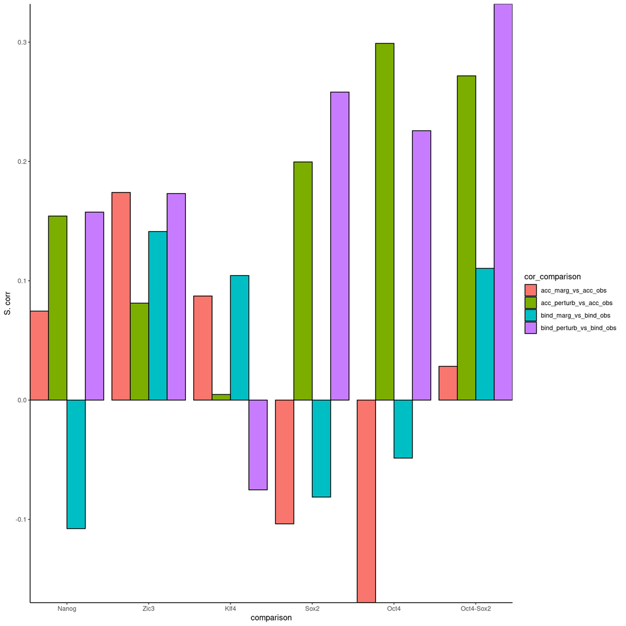

```r
cor.plot<-motifs.df %>%
  dplyr::group_by(motif) %>%
  # dplyr::slice_max(order_by = seq_match_quantile, n = 10000) %>%
  dplyr::summarize(bind_marg_vs_bind_obs = cor(bind_marg, bind_obs, method = 'spearman'),
                   bind_perturb_vs_bind_obs = cor(bind_perturb, bind_obs, method = 'spearman'),
                   acc_marg_vs_acc_obs = cor(acc_marg, atac_obs, method = 'spearman'),
                   acc_perturb_vs_acc_obs = cor(acc_perturb, atac_obs, method = 'spearman')) %>%
  dplyr::mutate(motif = factor(motif, levels = motif_to_task.list %>% names() %>% rev)) %>%
  tidyr::pivot_longer(cols = c(bind_marg_vs_bind_obs, bind_perturb_vs_bind_obs, acc_marg_vs_acc_obs, acc_perturb_vs_acc_obs), names_to = 'cor_comparison', values_to = 's_cor') %>%
  ggplot(., aes(x = motif, y = s_cor, fill = cor_comparison))+
  geom_bar(color = 'black', stat = 'identity', position = 'dodge')+
  # geom_text(aes(label = round(s_cor, 2)), color = 'black')+
  scale_x_discrete(name = 'comparison', expand = c(0,0))+
  scale_y_continuous(name = 'S. corr', expand = c(0,0))+
  # scale_fill_gradient2(high = '#b2182b', mid = 'white', low = '#2166ac', midpoint = 0, name = 'Spearman/corr')+
  theme_classic()
cor.plot
```

```r
ggsave(paste0(figure_filepath, '/model_pred_vs_obs_corr.png'), cor.plot, height = 4, width = 8)
ggsave(paste0(figure_filepath, '/model_pred_vs_obs_corr.pdf'), cor.plot, height = 4, width = 8)
```

# Explore variability of perturbation scores

Compare why perturbation scores are so variable.

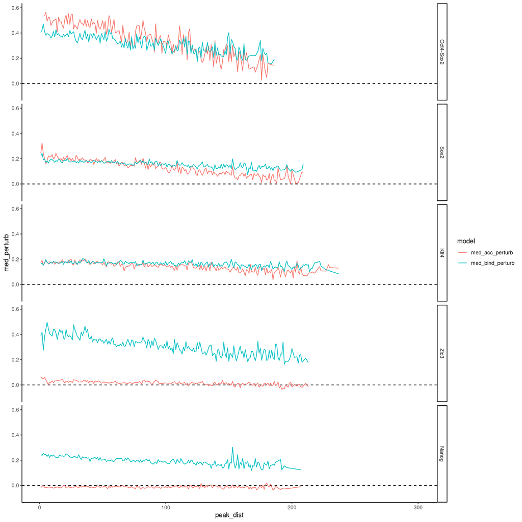

```r
count_threshold<-20

motifs_w_peak_dist.df<-motifs.df %>%
  dplyr::mutate(peak_dist = abs(pattern_center - 500),
                motif = factor(motif, levels = names(motif_to_task.list))) %>%
  dplyr::group_by(motif, peak_dist) %>%
  dplyr::summarize(med_bind_perturb = median(bind_perturb),
                   med_acc_perturb = median(acc_perturb),
                   counts = dplyr::n()) %>%
  dplyr::filter(counts>=count_threshold) %>%
  tidyr::pivot_longer(cols = c(med_bind_perturb, med_acc_perturb), names_to = 'model', values_to = 'med_perturb')

ggplot(motifs_w_peak_dist.df, aes(x = peak_dist, y = med_perturb, color = model))+
  geom_hline(yintercept = 0, linetype = 'dashed')+
  geom_line()+
  facet_grid(motif ~ .)+
    scale_x_continuous(limits = c(1, 300))+
    scale_y_continuous(limits = c(-.1, .6))+
  theme_classic()
```

# Showcase marginalization scores

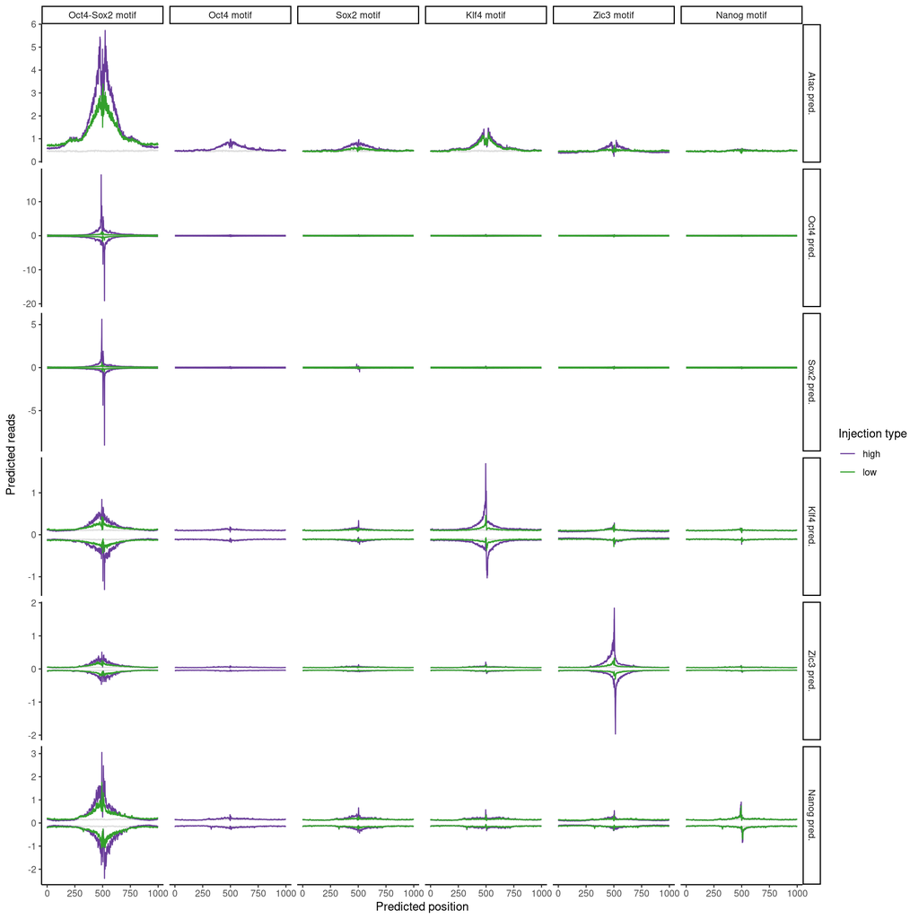

```r
showcase.df<-readr::read_tsv(showcase.path) %>%
  as.data.frame() %>%
  dplyr::filter(model_name %in% c('atac_wt', 'bpnet_osknz')) %>%
  dplyr::mutate(motif = factor(motif, levels = paste0(names(motif_to_task.list),  ' motif')),
                motif_vs_affinity = paste0(motif, ' ', affinity),
                task = factor(task, levels = c('Atac pred.', 'Oct4 pred.', 'Sox2 pred.', 'Klf4 pred.', 'Zic3 pred.', 'Nanog pred.')))

showcase.plot<-ggplot()+
  geom_line(data = showcase.df,
            mapping = aes(x = position, y = stranded_null_pred, group = channel), color = 'gray', alpha = .5)+
  geom_line(data = showcase.df,
            mapping = aes(x = position, y = stranded_pred, color = affinity, group = label))+
  scale_x_continuous(name = 'Predicted position')+
  scale_y_continuous(name = 'Predicted reads')+
  scale_color_manual(name = 'Injection type', values = c('#6a3d9a', '#33a02c', '#1f78b4'))+
  facet_grid(task ~ motif, scales = 'free_y')+
  theme_classic()

showcase.plot
```

```r
ggsave(paste0(figure_filepath, '/inj_showcase.plot.png'), showcase.plot, height = 10, width = 18)
ggsave(paste0(figure_filepath, '/inj_showcase.plot.pdf'), showcase.plot, height = 10, width = 18)
```

Showcase marginalization scores without Oct4-Sox2.

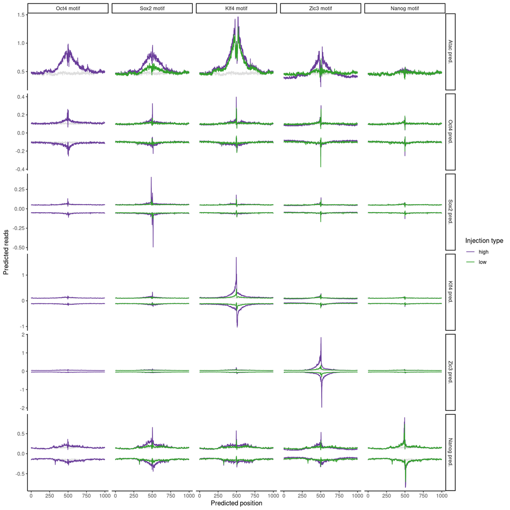

```r
showcase.plot<-ggplot()+
  geom_line(data = showcase.df %>% dplyr::filter(motif != 'Oct4-Sox2 motif'),
            mapping = aes(x = position, y = stranded_null_pred, group = channel), color = 'gray', alpha = .5)+
  geom_line(data = showcase.df %>% dplyr::filter(motif != 'Oct4-Sox2 motif'),
            mapping = aes(x = position, y = stranded_pred, color = affinity, group = label))+
  scale_x_continuous(name = 'Predicted position')+
  scale_y_continuous(name = 'Predicted reads')+
  scale_color_manual(name = 'Injection type', values = c('#6a3d9a', '#33a02c', '#1f78b4'))+
  facet_grid(task ~ motif, scales = 'free_y')+
  theme_classic()

showcase.plot
```

```r
ggsave(paste0(figure_filepath, '/inj_showcase_no_os.plot.png'), showcase.plot, height = 10, width = 15)
ggsave(paste0(figure_filepath, '/inj_showcase_no_os.plot.pdf'), showcase.plot, height = 10, width = 15)
```

# Showcase median context/isolation scores

Taking the median isolation scores and all corresponding motifs that match those sequences, plot a metapeak so people can see footprinting profiles.

First, import marginalization scores.

```r
marg_med.df<-readr::read_tsv('tsv/insilico/marginalizations/motifs/all_median_profiles.tsv.gz') %>%
  dplyr::filter(model_name %in% c('bpnet_osknz', 'atac_wt')) %>%
  dplyr::mutate(null_pred = ifelse(channel == 0, null_pred, null_pred * (-1)),
                marg_pred = ifelse(channel == 0, pred, pred * (-1))) %>%
  dplyr::group_by(position, channel, task, motif, model_name) %>%
  dplyr::summarize(med_pred = median(marg_pred), med_ref = median(null_pred)) %>%
  dplyr::mutate(position_wrt_motif = position - output_length/2)
```

Next, import binding perturbation scores and correct coordinates.

```r
context.df<-c('tsv/genomic/motifs/genomic_pertubs_median_motifs_formatted_bpnet_osknz.tsv.gz',
  'tsv/genomic/motifs/genomic_pertubs_median_motifs_formatted_atac_wt.tsv.gz') %>%
  lapply(., function(x){

    message(x)

    #Import perturbations
    perturb_all.df<-readr::read_tsv(x)

    #Import motifs and find relative coordinates and names
    perturb_motifs.df<-readr::read_tsv('tsv/genomic/motifs/medians_formatted_for_genomic_perturbations_0based.tsv.gz') %>%
      dplyr::group_by(region_id, motif) %>%
      dplyr::mutate(motif_num = dplyr::row_number(),
                    pattern_center = floor((motif_window_end - motif_window_start)/2) + motif_window_start - flank_length) %>%
      dplyr::ungroup() %>%
      dplyr::mutate(pattern_name_unique = paste0(motif, "-", motif_num)) %>% as.data.frame()

    #Align motif coordinates to neutral output prediction indexes
    perturb_ref.df<-perturb_all.df %>% dplyr::filter(mut=='Reference')
    perturb_mut.df<-perturb_all.df %>% dplyr::filter(mut!='Reference')
    rm(perturb_all.df)

    #Grab perturbations that are collected around the motifs, attach WT profile
    perturb_summary.df<-perturb_mut.df %>%
      dplyr::left_join(perturb_motifs.df %>%
                         dplyr::select(region_id, pattern_center, pattern_name_unique) %>%
                         dplyr::rename(mut = pattern_name_unique)) %>%
      dplyr::mutate(position_wrt_motif = window_position - pattern_center) %>%
      dplyr::group_by(region_id, mut) %>%
      dplyr::mutate(downstream_max = max(position_wrt_motif),
                    upstream_min = min(position_wrt_motif)) %>%
      dplyr::ungroup() %>%
      dplyr::filter(downstream_max>200, upstream_min < (-200), abs(position_wrt_motif)<200) %>% #plot a 400bp window, filter any motifs that don't make the cut
      dplyr::left_join(perturb_ref.df %>% dplyr::select(region_id, pred, window_position, model_name, task, channel) %>% dplyr::rename(ref_pred = pred)) %>%
      dplyr::mutate(mut = gsub('Oct4-Sox2', 'Oct4Sox2', mut)) %>%
      tidyr::separate(mut, into = c('motif', NA), sep = '-') %>%

      #Summarize results and plot profiles.
      dplyr::group_by(motif, position_wrt_motif, task, channel) %>%
      dplyr::summarize(med_pred = median(pred), med_ref = median(ref_pred)) %>%
      dplyr::mutate(med_pred = ifelse(channel %in% c('pos', 'atac'), med_pred, med_pred * (-1)),
                    med_ref = ifelse(channel %in% c('pos', 'atac'), med_ref, med_ref * (-1)))

    return(perturb_summary.df)
}) %>% rbindlist()
```

Plot the motifs effects with marginalization side by side

```r
interp_all.df<-rbind(
  marg_med.df %>% dplyr::mutate(task = gsub(' pred.', '', task) %>% tolower(.),
                                motif = gsub(' motif', '', motif),
                                channel = as.character(channel)) %>%
    dplyr::mutate(interp_type = 'marg', interp_score = med_pred - med_ref),
  context.df %>% dplyr::mutate(interp_type = 'context', interp_score = med_ref - med_pred)
) %>% dplyr::left_join(motif_to_task.df %>% dplyr::add_row(task = 'oct4', motif = 'Oct4Sox2') %>% dplyr::rename(intended_task = task)) %>%
  dplyr::filter((task==intended_task) | (task=='atac'))

overlaid_context_vs_marg.plot<-ggplot(interp_all.df, aes(x = position_wrt_motif, y = interp_score, group = channel, color = interp_type))+
  geom_line()+
  scale_x_continuous(limits = c(-200, 200))+
  facet_grid(task ~ motif, scales = 'free')+
  theme_classic()
ggsave(paste0(figure_filepath, '/marg_vs_perturb_profiles.png'), overlaid_context_vs_marg.plot, height = 14, width = 10)
ggsave(paste0(figure_filepath, '/marg_vs_perturb_profiles.pdf'), overlaid_context_vs_marg.plot, height = 14, width = 10)
```

# Directional OS <> N relationship across all marginalized values

## Compare predicted marginalizations of Nanog across OS motifs

Compare marginalization scores relative to accessibility and binding models.

```r
tf_at_os_motifs.plot.list<-lapply(names(motif_to_task.list), function(x){

  tf_marg_variable<-paste0(motif_to_task.list[[x]], '_marg')
  tf_at_os_motifs.plot<-motifs.df %>% dplyr::filter(motif=='Oct4-Sox2') %>%
  ggplot(., aes(x = !!sym(tf_marg_variable), y = acc_marg))+
    geom_hline(yintercept = 0, linetype = 'dotted')+
    geom_vline(xintercept = 0, linetype = 'dotted')+
    ggrastr::geom_point_rast(aes(color = seq_match_quantile), size = .1)+
    ggpubr::stat_cor(method = 'spearman', label.x.npc = 'left', label.y.npc = 'top')+
    scale_color_gradientn(colours = viridis(5), name = 'PWM score %ile')+
    scale_x_continuous(name = tf_marg_variable, limits = c(-.25, max(motifs.df$bind_marg)))+
    scale_y_continuous(name = 'Acc marg.', limits = c(-.25, max(motifs.df$acc_marg)))+
    ggtitle(paste0(tf_marg_variable, ' vs acc marg at OS motifs'))+
    theme_classic() + theme(legend.position = 'bottom')

  return(tf_at_os_motifs.plot)
})
tf_at_os_motifs.plot<-wrap_plots(tf_at_os_motifs.plot.list, nrow = 1)
ggsave(paste0(figure_filepath, '/marg_scores_over_os_motifs_across_other_tfs_vs_ic_scatter.png'), tf_at_os_motifs.plot, height = 4, width = 20)
ggsave(paste0(figure_filepath, '/marg_scores_over_os_motifs_across_other_tfs_vs_ic_scatter.pdf'), tf_at_os_motifs.plot, height = 4, width = 20)
```

## Compare experimental data across OS motifs

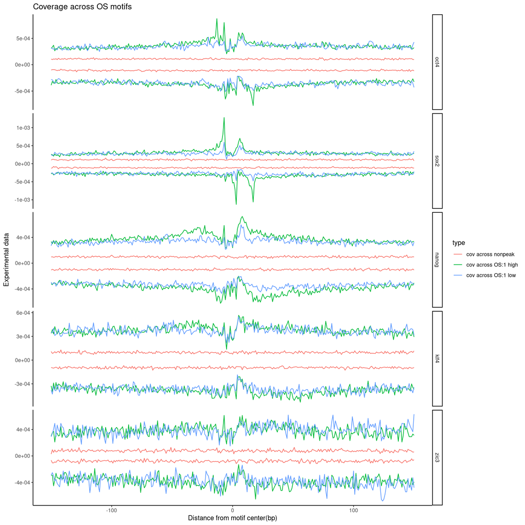

```r
isolated_os_motifs.gr<-motifs.df %>%
  dplyr::left_join(., regions.df %>% dplyr::select(region_id, island_content)) %>%
  dplyr::filter(motif=='Oct4-Sox2', island_content=='Oct4-Sox2:1') %>%
  makeGRangesFromDataFrame(keep.extra.columns = T, seqnames.field = 'seqnames', start.field = 'start', end.field = 'end',
                           strand.field = 'strand', starts.in.df.are.0based = T) %>%
  plyranges::filter(!overlapsAny(., rtracklayer::import('narrowpeak/mesc_nanog_nexus_peaks.bed'))) %>%
  GenomicRanges::resize(., 1, 'center')

nonpeak_of_nanog.gr<-rtracklayer::import('narrowpeak/mesc_atac_non_peaks.narrowPeak') %>%
    sample(size = isolated_os_motifs.gr %>%
             dplyr::filter(motif=='Oct4-Sox2') %>%
             dplyr::filter(island_content=='Oct4-Sox2:1') %>% length(), replace = F) %>%
    GenomicRanges::resize(., 1, 'center')

cov_across_os.df<-lapply(c('oct4','sox2','klf4','nanog','zic3'), function(x){
  message(x)

  #Filter to not contain any peak of TF that you're plotting across, avoiding direct profiles
  filtered.gr<-isolated_os_motifs.gr %>%
    plyranges::filter(!overlapsAny(., rtracklayer::import(paste0('narrowpeak/mesc_', x, '_nexus_peaks.bed'))))

  cov_across_os_high.df<-filtered.gr %>% plyranges::filter(seq_match_quantile>.5) %>%
    exo_metapeak(., sample = cov.bw.list[[x]], upstream = 150, downstream = 151) %>%
    dplyr::mutate(type = 'cov across OS:1 high',
                  tf = x)

  cov_across_os_low.df<-filtered.gr %>% plyranges::filter(seq_match_quantile<=.5) %>%
    exo_metapeak(., sample = cov.bw.list[[x]], upstream = 150, downstream = 151) %>%
    dplyr::mutate(type = 'cov across OS:1 low',
                  tf = x)

  cov_across_nonpeak.df<- nonpeak_of_nanog.gr%>%
    exo_metapeak(., sample = cov.bw.list[[x]], upstream = 150, downstream = 151) %>%
    dplyr::mutate(type = 'cov across nonpeak',
                  tf = x)
  df<-rbind(cov_across_os_high.df, cov_across_os_low.df, cov_across_nonpeak.df)
  return(df)
}) %>% rbindlist() %>%
  dplyr::mutate(tf = factor(tf, levels = c('oct4','sox2','nanog','klf4','zic3')))

cov_across_os.mp<-ggplot(cov_across_os.df, aes(x = tss_distance, y = reads, group = interaction(strand, type), color = type))+
  geom_line()+
  scale_x_continuous(name = 'Distance from motif center(bp)')+
  scale_y_continuous(name = 'Experimental data')+
  ggtitle('Coverage across OS motifs')+
  facet_grid(tf ~ ., scales = 'free')+
  theme_classic()
cov_across_os.mp
```

```r
ggsave(paste0(figure_filepath, '/os_vs_coverage_metapeak.plot.png'), cov_across_os.mp, height = 16, width = 6)
ggsave(paste0(figure_filepath, '/os_vs_coverage_metapeak.plot.pdf'), cov_across_os.mp, height = 16, width = 6)
```

For comparison, plot coverage at the Nanog motifs.

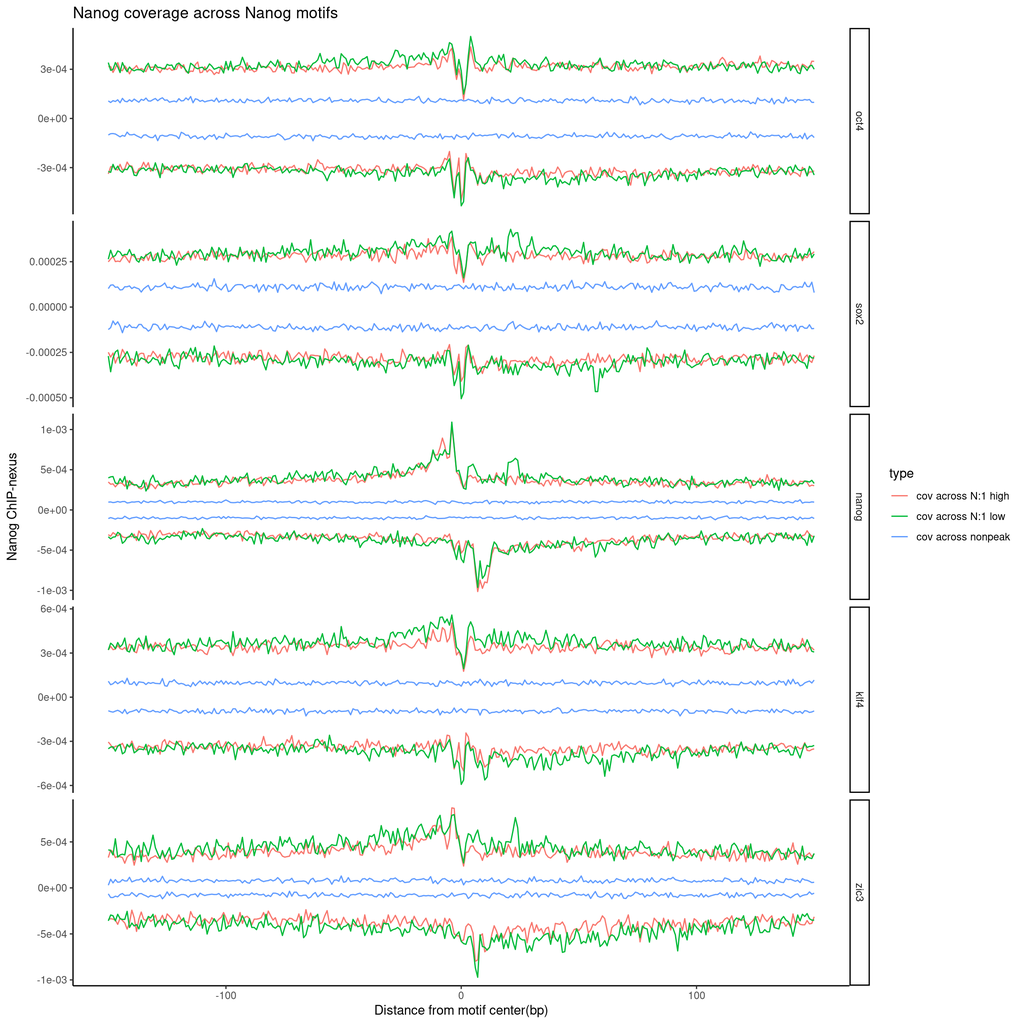

```r
isolated_nanog_motifs.gr<-motifs.df %>%
  dplyr::left_join(., regions.df %>% dplyr::select(region_id, island_content)) %>%
  dplyr::filter(motif=='Nanog') %>%
  dplyr::filter(island_content=='Nanog:1') %>%
  makeGRangesFromDataFrame(keep.extra.columns = T, seqnames.field = 'seqnames', start.field = 'start',
                           end.field = 'end', strand.field = 'strand', starts.in.df.are.0based = T) %>%
  GenomicRanges::resize(., 1, 'center')

cov_across_n.df<-mclapply(c('oct4','sox2','klf4','nanog','zic3'), function(x){
  message(x)

    #Filter to not contain any peak of TF that you're plotting across, avoiding direct profiles
  filtered.gr<-isolated_nanog_motifs.gr %>%
    plyranges::filter(!overlapsAny(., rtracklayer::import(paste0('narrowpeak/mesc_', x, '_nexus_peaks.bed'))))

  cov_across_n_high.df<-filtered.gr %>% plyranges::filter(seq_match_quantile>.5) %>%
    exo_metapeak(., sample = cov.bw.list[[x]], upstream = 150, downstream = 151) %>%
    dplyr::mutate(type = 'cov across N:1 high',
                  tf = x)

  cov_across_n_low.df<-filtered.gr %>% plyranges::filter(seq_match_quantile<=.5) %>%
    exo_metapeak(., sample = cov.bw.list[[x]], upstream = 150, downstream = 151) %>%
    dplyr::mutate(type = 'cov across N:1 low',
                  tf = x)

  cov_across_nonpeak.df<-nonpeak_of_nanog.gr %>%
    exo_metapeak(., sample = cov.bw.list[[x]], upstream = 150, downstream = 151) %>%
    dplyr::mutate(type = 'cov across nonpeak',
                  tf = x)
  df<-rbind(cov_across_n_high.df, cov_across_n_low.df, cov_across_nonpeak.df)
  return(df)
}, mc.cores = 6) %>% rbindlist() %>%
  dplyr::mutate(tf = factor(tf, levels = c('oct4','sox2','nanog','klf4','zic3')))

cov_across_n.mp<-ggplot(cov_across_n.df, aes(x = tss_distance, y = reads, group = interaction(strand, type), color = type))+
  geom_line()+
  scale_x_continuous(name = 'Distance from motif center(bp)')+
  scale_y_continuous(name = 'Nanog ChIP-nexus')+
  ggtitle('Nanog coverage across Nanog motifs')+
  facet_grid(tf ~ ., scales = 'free')+
  theme_classic()
cov_across_n.mp
```

```r
ggsave(paste0(figure_filepath, '/n_vs_coverage_metapeak.plot.png'), cov_across_n.mp, height = 20, width = 6)
ggsave(paste0(figure_filepath, '/n_vs_coverage_metapeak.plot.pdf'), cov_across_n.mp, height = 20, width = 6)
```